# DATA 606, Chapter 4 – Foundations for Inference

Kavya Beheraj

March 18, 2018

## 4.4 Heights of adults

#### (a) What is the point estimate for the average height of active individuals? What about the median?

- Point estimate for average height = **171.1 cm**
- Point estimate for median height = **170.3 cm**

#### (b) What is the point estimate for the standard deviation of the heights of active individuals? What about the IQR?

- Point estimate for standard deviation = **9.4 cm**
- Point estimate for IQR = 177.8 – 163.8 = **14 cm**

#### (c) Is a person who is 1m 80cm (180 cm) tall considered unusually tall? And is a person who is 1m 55cm (155cm) considered unusually short? Explain your reasoning.

- A person who is 180 cm tall is $\frac{|180 - 171.1|}{9.4} \approx$ **0.947** standard deviations away from the mean.
- This is **not unusual**.
- A person who is 155 cm tall is $\frac{|155 - 171.1|}{9.4} \approx$ **1.71** standard deviations away from the mean.
- This is **more unusual**.

#### (d) The researchers take another random sample of physically active individuals. Would you expect the mean and the standard deviation of this new sample to be the ones given above? Explain your reasoning.

- I would expect both the sample mean and standard deviation to be different, because they are just estimates of the population, and will change each time.

#### (e) The sample means obtained are point estimates for the mean height of all active individuals, if the sample of individuals is equivalent to a simple random sample. What measure do we use to quantify the variability of such an estimate? Compute this quantity using the data from the original sample under the condition that the data are a simple random sample.

- We use **standard error** to compute the variability of a sample.
- Standard Error = $\frac{171.1}{\sqrt(507)} =$ **7.6**

  ```r
  171.1 / sqrt(507)
  ```

  ```
  ## [1] 7.598818
  ```

## 4.14 Thanksgiving Spending, Part I

#### (a) We are 95% confident that the average spending of these 436 American adults is between $80.31 and 89.11.

- **FALSE**. The confidence interval applies to the population, not the sample.

#### (b) This confidence interval is not valid since the distribution of spending in the sample is right skewed.

- **TRUE**. The confidence interval assumes a normal distribution, so a highly-skewed sample makes it less reliable.

#### (c) 95% of random samples have a sample mean between $80.31 and 89.11.

- **FALSE**. This is not the correct interpretation of a confidence interval.

#### (d) We are 95% confident that the average spending of all American adults is between $80.31 and 89.11.

- **TRUE**. This is the correct interpretation of a confidence interval.

#### (e) A 90% confidence interval would be narrower than the 95% confidence interval since we don’t need to be as sure about our estimate.

- **TRUE**. At a 90% confidence level, we are less sure that the population parameter falls within the interval.

#### (f) In order to decrease the margin of error of a 95% confidence interval to a third of what it is now, we would need to use a sample 3 times larger.

- **FALSE**. In order to decrease the margin of error, we would need to sample $3^2=9$ times the number of people in the initial sample.

#### (g) The margin of error is 4.4.

- **FALSE**. The margin of error is $3.85.

  ```r
  (0.95) * (84.71 / sqrt(436))
  ```

  ```
  ## [1] 3.85403
  ```

## 4.24 Gifted Children, Part I

#### (a) Are conditions for inference satisfied?

- **Yes.** The sample is random, so the observations are independent. The sample size is above 30. The sample does not appear to be strongly skewed in one direction.

#### (b) Suppose you read online that children first count to 10 successfully when they are 32 months old, on average. Perform a hypothesis test to evaluate if these data provide convincing evidence that the average age at which gifted children first count to 10 successfully is less than the general average of 32 months. Use a significance level of 0.10.

- $H_0 : \mu = 32$
- $H_A : \mu \neq 32$
- $Z = \frac{|30.69-32|}{36} = 0.036$
- p-value = 0.971282
- $\alpha = 0.10$
- p-value $>\alpha$, so the result is not significant. We accept the null hypothesis. The data does not provide convincing evidence that the average age for gifted children is less than the general average.

#### (c) Interpret the p-value in context of the hypothesis test and the data.

- The p-value is larger than the alpha. This provides strong evidence to accept the null hypothesis as true.

#### (d) Calculate a 90% confidence interval for the average age at which gifted children first count to 10 successfully.

  ```r
  30.69 + (0.9 * (4.31 / sqrt(36)))
  ```

  ```
  ## [1] 31.3365
  ```

  ```r
  30.69 - (0.9 * (4.31 / sqrt(36)))
  ```

  ```
  ## [1] 30.0435
  ```

#### (e) Do your results from the hypothesis test and the confidence interval agree? Explain.

- No. The average age for all children falls above the confidence interval for the population of gifted children.

## 4.26 Gifted Children, Part II

#### (a) Perform a hypothesis test to evaluate if these data provide convincing evidence that the average IQ of mothers of gifted children is different than the average IQ for the population at large, which is 100. Use a significance level of 0.10.

- $H_0 : \mu = 100$
- $H_A : \mu \neq 100$
- $Z = \frac{|118.2-100|}{36} \approx 0.51$
- p-value = 0.610051
- $\alpha = 0.10$
- p-value $>\alpha$, so the result is not significant. We accept the null hypothesis. The data does not provide convincing evidence that the average IQ of mothers of gifted children is different that the average IQ of the population at large.

#### (b) Calculate a 90% confidence interval for the average IQ of mothers of gifted children.

- A 90% confidence interval for this sample is **(117.23, 119.18).**

  ```r
  118.2 + (0.9 * (6.5 / sqrt(36)))
  ```

  ```
  ## [1] 119.175
  ```

  ```r
  118.2 - (0.9 * (6.5 / sqrt(36)))
  ```

  ```
  ## [1] 117.225
  ```

#### (c) Do your results from the hypothesis test and the confidence interval agree? Explain.

- No. The average IQ of the mothers of normal children falls below the confidence interval for the population of the mothers of gifted children.

## 4.34 CLT

#### Define the term “sampling distribution” of the mean, and describe how the shape, center, and spread of the sampling distribution of the mean change as sample size increases.

- The sampling distribution represents the distribution of point estimates based on samples of a fixed size from a certain population. As the sample size increases, the distribution becomes less skewed more normal.

## 4.40 CFLBs

Mean = 9000 hours SD = 1000 hours

#### (a) What is the probability that a randomly chosen light bulb lasts more than 10,500 hours?

- The probability is about **6.7%**.

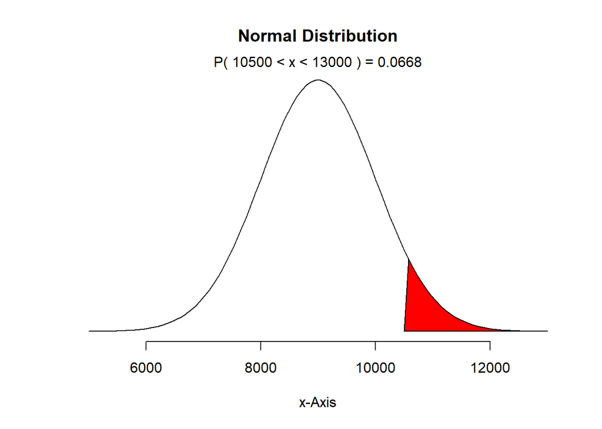

```r
normalPlot(mean = 9000, sd = 1000, bounds = c(10500, 13000), tails = FALSE)
```

#### (b) Describe the distribution of the mean lifespan of 15 light bulbs.

- The population standard deviation is known and the data are nearly normal, so the sample mean will be nearly normal with the distribution N(mean = 9000, SE = 258.2).

#### (c) What is the probability that the mean lifespan of 15 randomly chosen light bulbs is more than 10,500 hours?

- P(mean > 10500) = essentially **0.0**

```r
mu <- 9000
stdev <- 1000
se <- stdev / sqrt(15)
se
```

```
## [1] 258.1989
```

```r
z <- (10500-9000)/se
pv <- pnorm(z, mean = mu, sd = stdev)

pv
```

```
## [1] 1.189897e-19
```

#### (d) Sketch the two distributions (population and sampling) on the same scale.

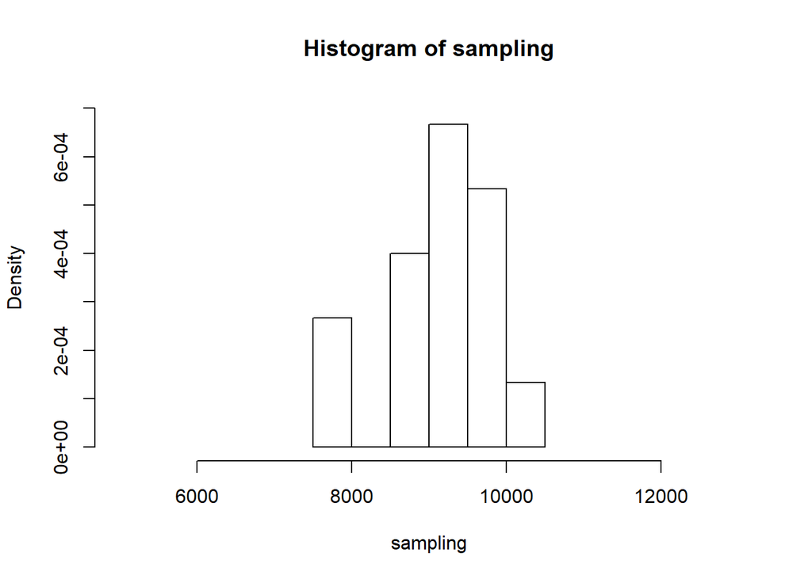

```r
sampling <- rnorm(15, mean = 9000, sd = 1000)

population <- rnorm(15000, mean = 9000, sd = 1000)

hist(sampling, freq = FALSE, xlim=c(5000,13000), ylim=c(0, 7e-04))
```

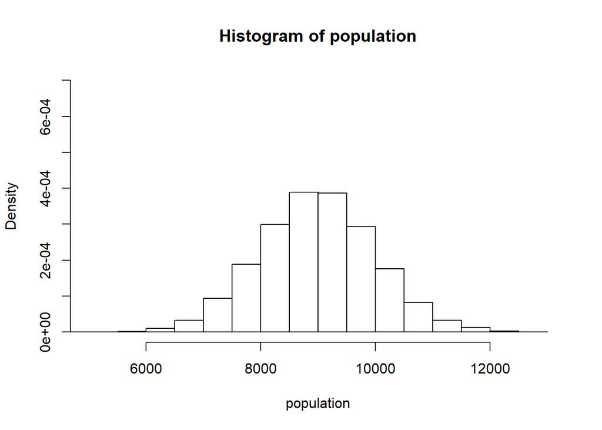

```r
hist(population, freq = FALSE, xlim=c(5000,13000), ylim=c(0, 7e-04))
```

#### (e) Could you estimate the probabilities from parts (a) and (c) if the lifespans of light bulbs had a skewed distribution?

- No. We cannot estimate probabilities using a skewed distribution, since an assumption we make is that the distribution is normal.

## 4.48 Same Observation, Different Sample Size

#### Suppose you conduct a hypothesis test based on a sample where the sample size is n = 50, and arrive at a p-value of 0.08. You then refer back to your notes and discover that you made a careless mistake, the sample size should have been n = 500. Will your p-value increase, decrease, or stay the same? Explain.

The standard error from the first to the second sample will greatly decrease.

[output not shown]

Standard error becomes the denominator of the Z-Score. As the sample increases, and the standard error decreases, the Z-Score will increase.

If the Z-Score increases, that means that the p-value will decrease.